# Data Visualization

Quan Gan

2022-04-12

# Data

The data set, [US Accidents (2016 - 2021)](https://www.kaggle.com/datasets/sobhanmoosavi/us-accidents?resource=download), comes from Kaggle collected by Moosavi et al. The data set’s authors already published a research paper about accident risk prediction. There are 2.8 million car accident records which covers 49 states of the USA from February 2016 to December 2021 in the data set. In the data set, there are 47 attributes regarding the car accident details. These records were captured by a variety of US traffic department APIs such as the US and state departments of transportation, law enforcement agencies and so on.

```r
# load data in
car_accident_covid <- read_csv("./data/car_accidents_cleaned.csv")
```

# Research Question

During the COVID-19 pandemic from January 20, 2020 to December 2021:

1. which US states have most car accidents?
2. Which weather conditions cause more car accidents across different severity in the US?
3. How do car accident amounts change by time series?

## Research Question 1

which US states have most car accidents?

### Data Inspection

```r
cases <- car_accident_covid %>%
  count(State)

cases_state <- data.frame(cases)

cases_df <- cbind(cases_state[1:7,],
                  cases_state[8:14,],
                  cases_state[15:21, ],
                  cases_state[22:28,],
                  cases_state[29:35,],
                  cases_state[36:42,],
                  cases_state[43:49,])

htmlTable(cases_df,
          cgroup = c("Set 1:7", "Set 8:14", "Set 15:21", "Set 22:28","Set 29:35", "Set 36:42", "Set 43:49"),
          n.cgroup = c(2,2,2,2,2,2,2),
          rnames = FALSE,
          caption = "A table contains car accident amount in different states")
```

| A table contains car accident amount in different states Set 1:7 State | A table contains car accident amount in different states Set 1:7 n | A table contains car accident amount in different states | A table contains car accident amount in different states Set 8:14 State | A table contains car accident amount in different states Set 8:14 n | A table contains car accident amount in different states | A table contains car accident amount in different states Set 15:21 State | A table contains car accident amount in different states Set 15:21 n | A table contains car accident amount in different states | A table contains car accident amount in different states Set 22:28 State | A table contains car accident amount in different states Set 22:28 n | A table contains car accident amount in different states | A table contains car accident amount in different states Set 29:35 State | A table contains car accident amount in different states Set 29:35 n | A table contains car accident amount in different states | A table contains car accident amount in different states Set 36:42 State | A table contains car accident amount in different states Set 36:42 n | A table contains car accident amount in different states | A table contains car accident amount in different states Set 43:49 State | A table contains car accident amount in different states Set 43:49 n |
| --- | --- | --- | --- | --- | --- | --- | --- | --- | --- | --- | --- | --- | --- | --- | --- | --- | --- | --- | --- |
| AL | 16558 |  | DE | 3692 |  | KS | 5609 |  | MN | 74386 |  | NH | 455 |  | OR | 71112 |  | UT | 26034 |
| AR | 9590 |  | FL | 354739 |  | KY | 3071 |  | MO | 18208 |  | NJ | 36991 |  | PA | 88924 |  | VA | 96785 |
| AZ | 43897 |  | GA | 20583 |  | LA | 43780 |  | MS | 3684 |  | NM | 1502 |  | RI | 1487 |  | VT | 75 |
| CA | 571355 |  | IA | 7126 |  | MA | 3145 |  | MT | 15515 |  | NV | 3298 |  | SC | 83604 |  | WA | 15914 |
| CO | 12159 |  | ID | 6893 |  | MD | 51393 |  | NC | 73172 |  | NY | 80042 |  | SD | 149 |  | WI | 1080 |
| CT | 21755 |  | IL | 16966 |  | ME | 163 |  | ND | 2228 |  | OH | 9970 |  | TN | 44629 |  | WV | 5667 |
| DC | 7878 |  | IN | 13655 |  | MI | 25396 |  | NE | 1989 |  | OK | 6828 |  | TX | 109941 |  | WY | 676 |

### Data Visulization

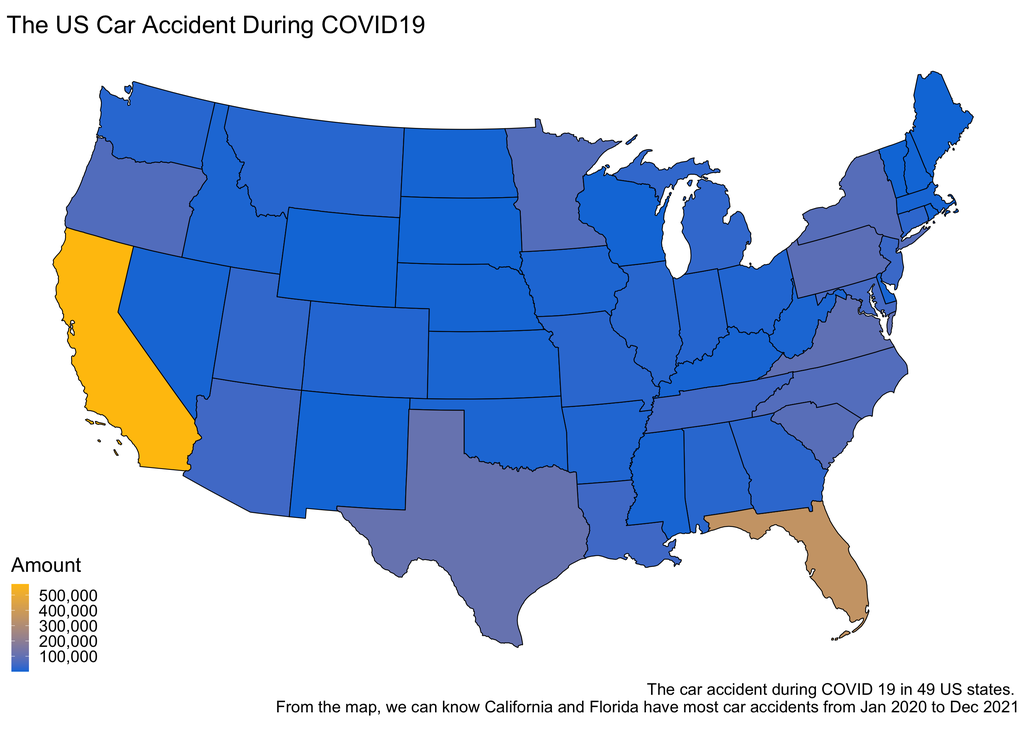

```r
cases_2 <- cases %>% rename(state = State)

state_info <- data.frame(state = state.abb,
                         region = tolower(state.name))

car_data <- state_info %>%
  left_join(cases_2)

car_data %>%
  plot_usmap(data =.,
             values = "n",
             exclude = c("AK","HI")) +
  scale_fill_continuous(high = "#FFC20A", low= "#0C7BDC", name="Amount",
          label = scales::comma) +
  theme(text = element_text(size = 20))  +
  labs(title = "The US Car Accident During COVID19",
       caption = "The car accident during COVID 19 in 49 US states. \nFrom the map, we can know California and Florida have most car accidents from Jan 2020 to Dec 2021")
```

From the above map, we could know California and Florida have most car accidents from Jan 2020 to Dec 2021 during the COVID 19. Most of states have fewer car accidents. The main car accidents occured in the border states.

## Research Question 2

Which weather conditions cause more car accidents across different severity in the US?

### Data Inspection

```r
weather <- car_accident_covid %>%
  filter(!is.na(Weather_Condition)) %>%
  count(Weather_Condition) %>%
  arrange(desc(n)) %>%
  top_n(10)

weather %>% kable()
```

| Weather_Condition | n |
| --- | --- |
| Fair | 999381 |
| Cloudy | 311689 |
| Mostly Cloudy | 267339 |
| Partly Cloudy | 176984 |
| Light Rain | 94117 |
| Fog | 35316 |
| Light Snow | 29812 |
| Haze | 26965 |
| Rain | 22925 |
| Fair / Windy | 13703 |